# Simulating alpha diversity

# How do diversity measures look at complete evenness

Observations

- Range of Shannon : 0 to infinity
- Range of Simpson : bounded between 1 and 0
- Simpson tends to peak for full evenness at small number of individuals (~10 or 15)
- Shannon does not plateau for evenness as the number of individual increases

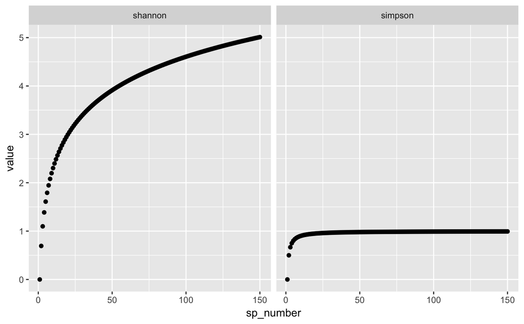

```r
n_individuals <- 150
df1 <- tibble(
  sp_number=seq(1,n_individuals),
  shannon=map_dbl(seq(1,n_individuals), function(x) diversity( rep(100/x,x) ,index="shannon")),
  simpson=map_dbl(seq(1,n_individuals), function(x) diversity( rep(100/x,x) ,index="simpson"))
  #inv_simpson=map_dbl(seq(1,n_individuals), function(x) diversity( rep(100/x,x) ,index="invsimpson"))
) %>% gather(key="index",value="value",-sp_number)
ggplot(df1,aes(sp_number,value)) + geom_point() + facet_wrap(~index)
```

# How do Simpson and Shannon behave with skewed distributions

Set up a simulation as follows: Choose

- n_bugs: number of individuals in the microbiome
- Dominant bugs: We simulate dominant bugs, by deciding
  - how many bugs dominate the sample (n_dominant)
  - what share of the % they take (pct_dominance)

  Then, we simulate each bug’s abundance as normally distributed,
  - with mean= pct_dominance / n_dominant
  - sd = dominance_sd
- Tail bugs: For the rest of the bugs (n_bugs - n_dominant), each of their abundance is simulated similarly, normally distributed
  - mean = (1 - pct_dominance) / (n_bugs - n_dominant)
  - sd = tail_sd

Both dominant bugs and tail bug’s abundances are normalized individually, so that final sum is as specified

```r
simulate_skewed_dist <- function(n_bugs,n_dominant,pct_dominance,dominance_sd=0.2,tail_sd=0.33){

  dominant_bugs <- rnorm(n=n_dominant,mean=(pct_dominance/n_dominant),sd=dominance_sd*(pct_dominance/n_dominant))
  dominant_bugs.norm <- pct_dominance * dominant_bugs / sum(dominant_bugs)

  n_tail = n_bugs - n_dominant
  tail_bugs <- rnorm(n=n_tail,mean=(100-pct_dominance),sd=(100-pct_dominance)*tail_sd)
  #correct 0's
  tail_bugs[tail_bugs < 0] <- (100-pct_dominance)
  tail_bugs.norm <- (100-pct_dominance) * tail_bugs / sum(tail_bugs)
  return(c(dominant_bugs.norm,tail_bugs.norm))
}
```

## Set up simulation

For the simulation, we will try the combination of all of the following parameters

- Number of individuals : from 30, 35, 40, 45 … 80
- Number of dominant bugs per sample: between 1 and 6
- % dominance: 50 to 96 in steps of 9

```r
n_bugs <- seq(30,80,5)
n_dominant_bugs <- 1:6
dominant_pct <- seq(50,96,9)
simulations <- expand.grid(n_bugs,n_dominant_bugs,dominant_pct) %>% data.frame
colnames(simulations) <- c("bugs",'dominant_bugs','dominant_pct')
```

## Run simulations

```r
#could fail if dominance Std dev makes values become negative
microbiomes <- pmap(simulations, function(bugs,dominant_bugs,dominant_pct,...) replicate(50,simulate_skewed_dist(bugs,dominant_bugs,dominant_pct)))
shannon <- map(microbiomes,function(sim) diversity(t(sim),index="shannon"))
simpson <- map(microbiomes,function(sim) diversity(t(sim),index="simpson"))
invsimpson <- map(microbiomes,function(sim) diversity(t(sim),index="invsimpson"))
simulations$shannon.mean <- map_dbl(shannon,mean)
simulations$shannon.sd <- map_dbl(shannon,sd)
simulations$simpson.mean <- map_dbl(simpson,mean)
simulations$simpson.sd <- map_dbl(simpson,sd)
simulations$invsimpson.mean <- map_dbl(invsimpson,mean)
simulations$invsimpson.sd <- map_dbl(invsimpson,sd)
```

# Plot one simulation to exemplify

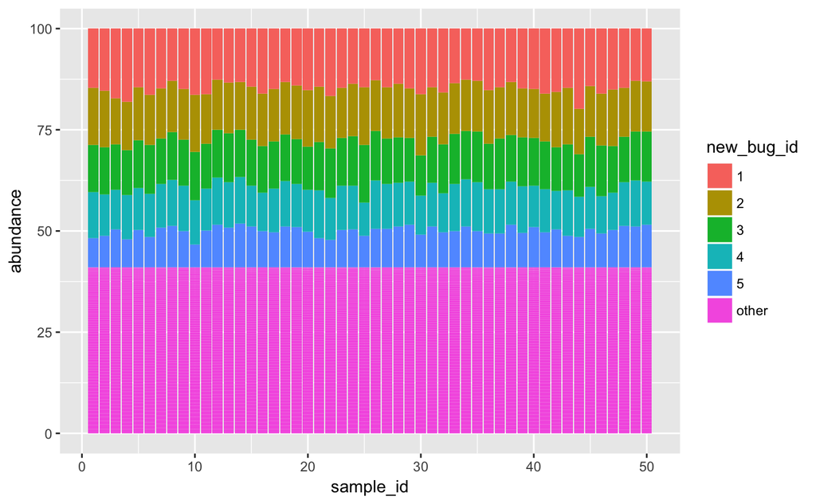

```r
long.example <- apply(microbiomes[[120]],2,sort,decreasing=T) %>%
  data.frame %>%
  tibble::rownames_to_column(var="bug_id") %>%
  gather(key="sample_id",value="abundance",-bug_id) %>%
  extract(sample_id,into="sample_id",regex="X(.+)",convert=TRUE) %>%
  group_by(sample_id) %>%
  mutate(bug_rank=rank(-abundance,ties.method="first"),new_bug_id=map_chr(bug_rank,~ifelse(.x <= 5,.x,"other"))) %>%
  ungroup()
ggplot(long.example,aes(sample_id,abundance)) + geom_bar(aes(fill=new_bug_id),stat="identity",position = 'stack') + coord_cartesian(ylim=c(0,100))
```

# Shannon diversity

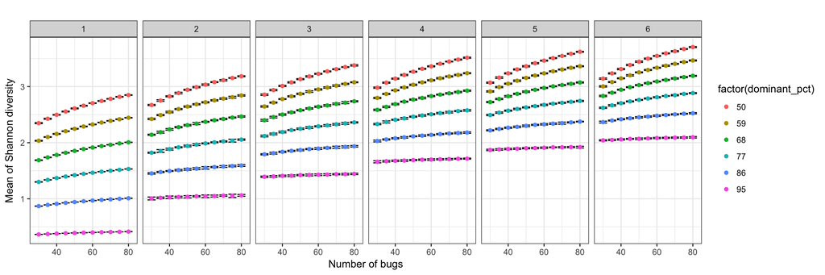

```r
ggplot(simulations,aes(bugs,shannon.mean)) +
  geom_errorbar(aes(ymin=shannon.mean-shannon.sd,ymax=shannon.mean+shannon.sd)) +
  geom_point(aes(color=factor(dominant_pct))) +
  facet_wrap(~dominant_bugs,nrow=1) + theme_bw() +
  xlab("Number of bugs") + ylab("Mean of Shannon diversity") + ggtitle("")
```

# Shannon diversity by number of species

From this plot it appears the shannon diversity is way more driven by number of dominant species, than by number of species. The value for diversity when there are few and strongly dominating species does not change a lot when varying the number of individuals in the sample

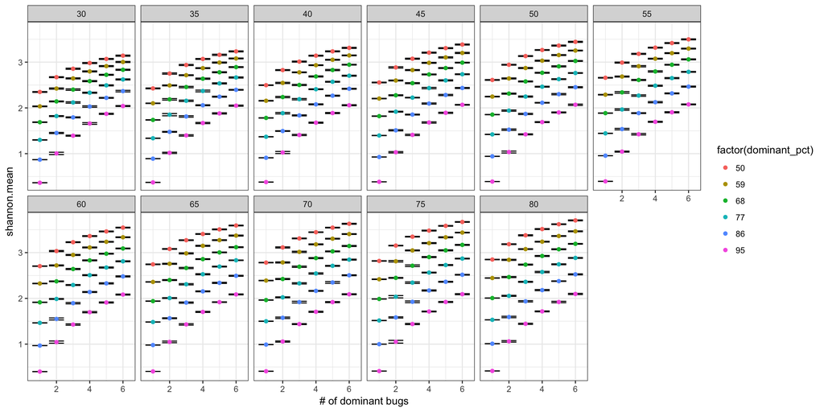

```r
ggplot(simulations,aes(dominant_bugs,shannon.mean)) +
  geom_errorbar(aes(ymin=shannon.mean-shannon.sd,ymax=shannon.mean+shannon.sd)) +
  geom_point(aes(color=factor(dominant_pct))) +
  facet_wrap(~bugs,nrow=2) + theme_bw() +
  xlab("# of dominant bugs")
```

# Simpson

This index appears to be more driven by evenness.

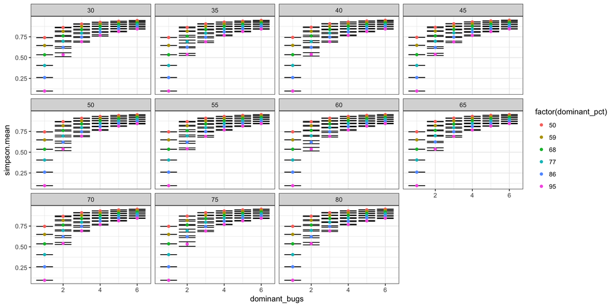

```r
ggplot(simulations,aes(dominant_bugs,simpson.mean)) +
  geom_errorbar(aes(ymin=simpson.mean-simpson.sd,ymax=simpson.mean+simpson.sd)) +
  geom_point(aes(color=factor(dominant_pct))) + facet_wrap(~bugs) +
  theme_bw()
```

# Inverse simpson

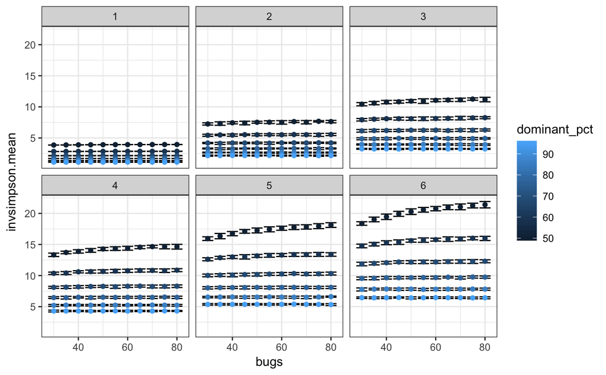

```r
ggplot(simulations,aes(bugs,invsimpson.mean)) +
  geom_errorbar(aes(ymin=invsimpson.mean-invsimpson.sd,ymax=invsimpson.mean+invsimpson.sd)) +
  geom_point(aes(color=dominant_pct)) +
  facet_wrap(~dominant_bugs) + theme_bw()
```